# Wine Analysis by Mathias Wainer

This dataset is composed of 1599 observations of different red wines and 11 variables. The dataset was created by: Paulo Cortez (Univ. Minho), Antonio Cerdeira, Fernando Almeida, Telmo Matos and Jose Reis. By making this data publicly available it allows everyone to explore and come up with original analysis. The output variable (y) is the quality of wine as determined by wine someliers. It is the hope of the creators and anyone who explores the data to come up with conclusions on what variables make the best wines.

# Univariate Plots Section

```
##  [1] "X"                    "fixed.acidity"        "volatile.acidity"
##  [4] "citric.acid"          "residual.sugar"       "chlorides"
##  [7] "free.sulfur.dioxide"  "total.sulfur.dioxide" "density"
## [10] "pH"                   "sulphates"            "alcohol"
## [13] "quality"
```

```
##        X          fixed.acidity   volatile.acidity  citric.acid
##  Min.   :   1.0   Min.   : 4.60   Min.   :0.1200   Min.   :0.000
##  1st Qu.: 400.5   1st Qu.: 7.10   1st Qu.:0.3900   1st Qu.:0.090
##  Median : 800.0   Median : 7.90   Median :0.5200   Median :0.260
##  Mean   : 800.0   Mean   : 8.32   Mean   :0.5278   Mean   :0.271
##  3rd Qu.:1199.5   3rd Qu.: 9.20   3rd Qu.:0.6400   3rd Qu.:0.420
##  Max.   :1599.0   Max.   :15.90   Max.   :1.5800   Max.   :1.000
##  residual.sugar     chlorides       free.sulfur.dioxide
##  Min.   : 0.900   Min.   :0.01200   Min.   : 1.00
##  1st Qu.: 1.900   1st Qu.:0.07000   1st Qu.: 7.00
##  Median : 2.200   Median :0.07900   Median :14.00
##  Mean   : 2.539   Mean   :0.08747   Mean   :15.87
##  3rd Qu.: 2.600   3rd Qu.:0.09000   3rd Qu.:21.00
##  Max.   :15.500   Max.   :0.61100   Max.   :72.00
##  total.sulfur.dioxide    density             pH          sulphates
##  Min.   :  6.00       Min.   :0.9901   Min.   :2.740   Min.   :0.3300
##  1st Qu.: 22.00       1st Qu.:0.9956   1st Qu.:3.210   1st Qu.:0.5500
##  Median : 38.00       Median :0.9968   Median :3.310   Median :0.6200
##  Mean   : 46.47       Mean   :0.9967   Mean   :3.311   Mean   :0.6581
##  3rd Qu.: 62.00       3rd Qu.:0.9978   3rd Qu.:3.400   3rd Qu.:0.7300
##  Max.   :289.00       Max.   :1.0037   Max.   :4.010   Max.   :2.0000
##     alcohol         quality
##  Min.   : 8.40   Min.   :3.000
##  1st Qu.: 9.50   1st Qu.:5.000
##  Median :10.20   Median :6.000
##  Mean   :10.42   Mean   :5.636
##  3rd Qu.:11.10   3rd Qu.:6.000
##  Max.   :14.90   Max.   :8.000
```

```
##    Min. 1st Qu.  Median    Mean 3rd Qu.    Max.
##   3.000   5.000   6.000   5.636   6.000   8.000
```

```
##
##     3     4     5     6     7     8
## 0.006 0.033 0.426 0.399 0.124 0.011
```

We can see above x being all the observations, the 11 variables and ‘quality’ as the output variable. We also can look at the summary statistics for each one. Quality was printed again since it should be our focus to decipher how it is shaped by every variable.

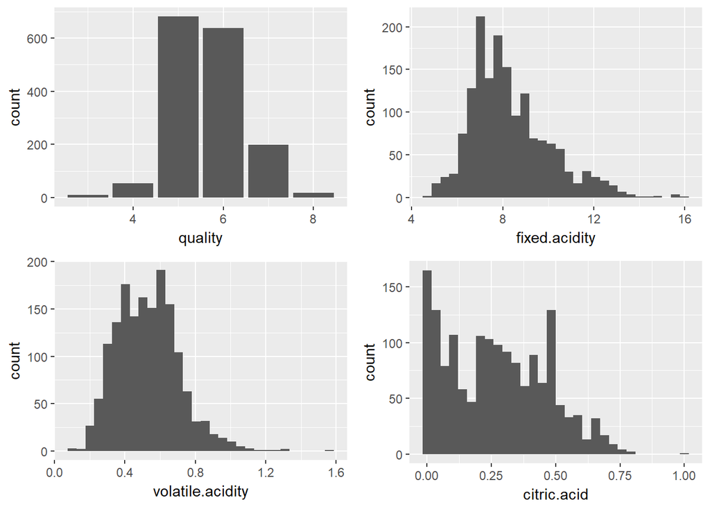

We can see that quality is clustred around scores 5 and 6 (80% of observations). Both fixed and volatile acidities follow what appears to be a normal distribution. Citric.acid does not follow a normal distribution and may even be bimodal.

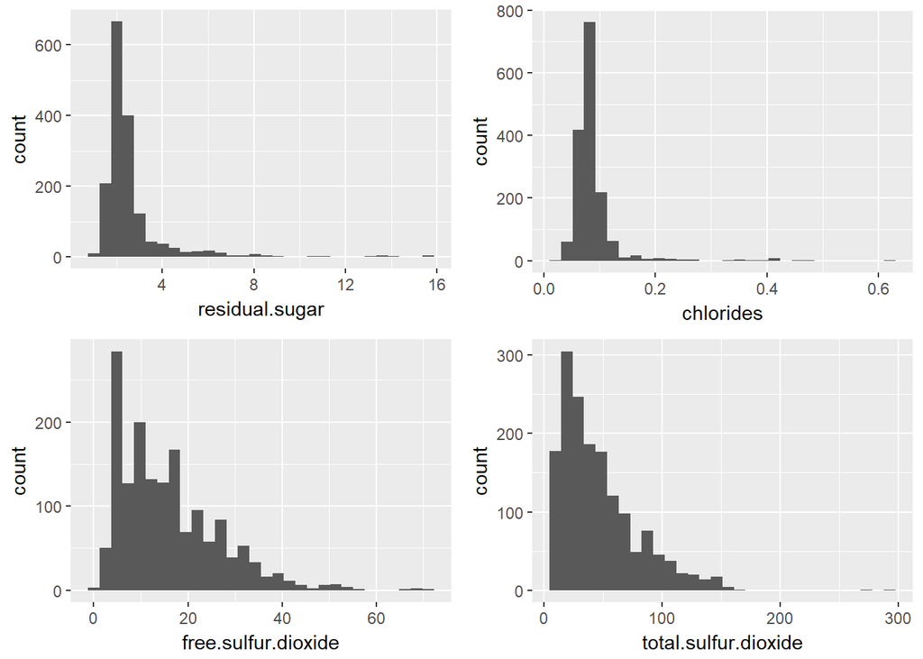

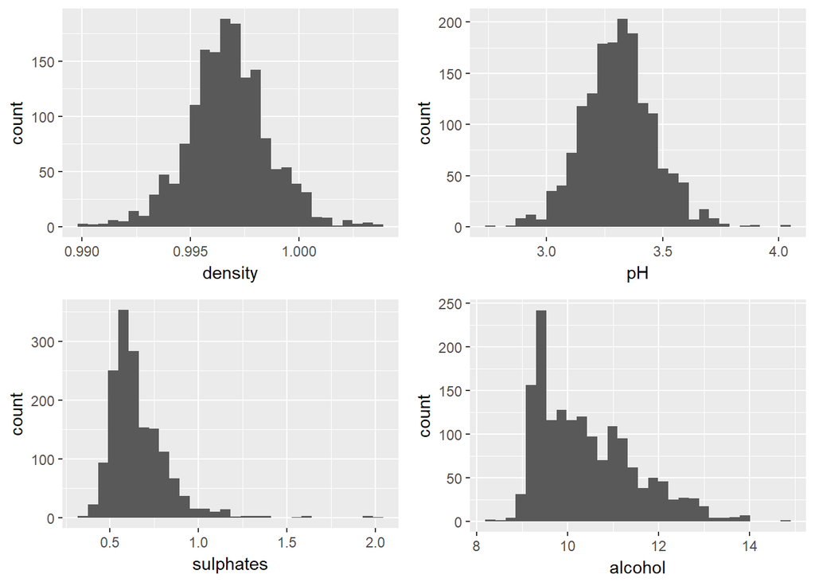

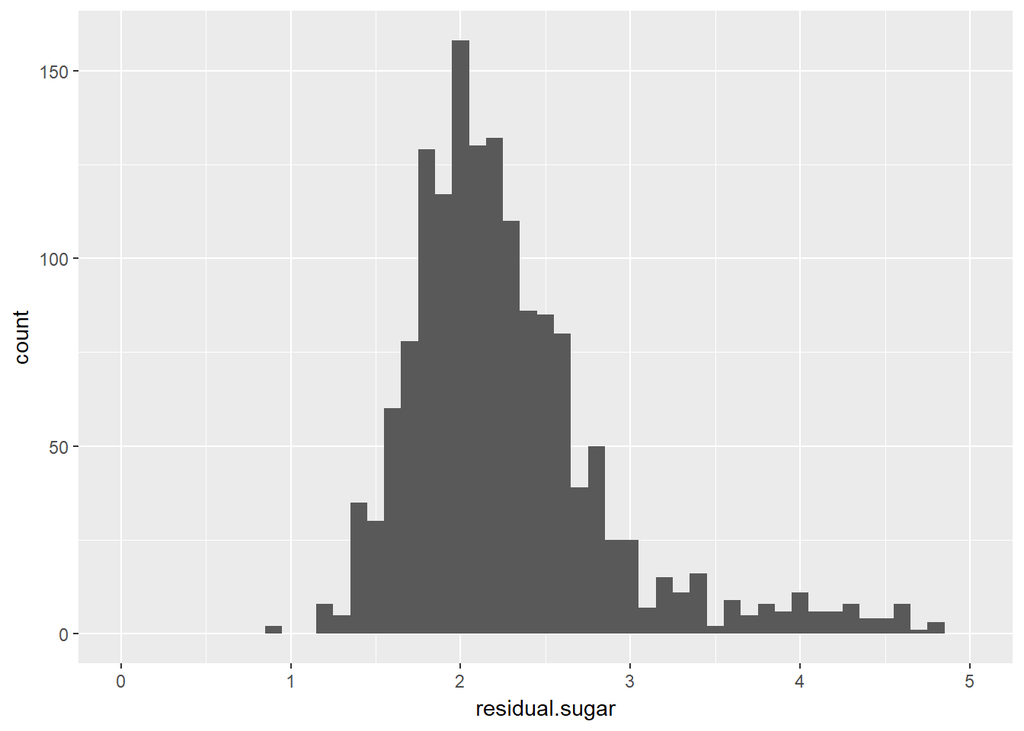

After limiting the x axis for residual.sugar we can see the distribution be more normal and center around 2.25.

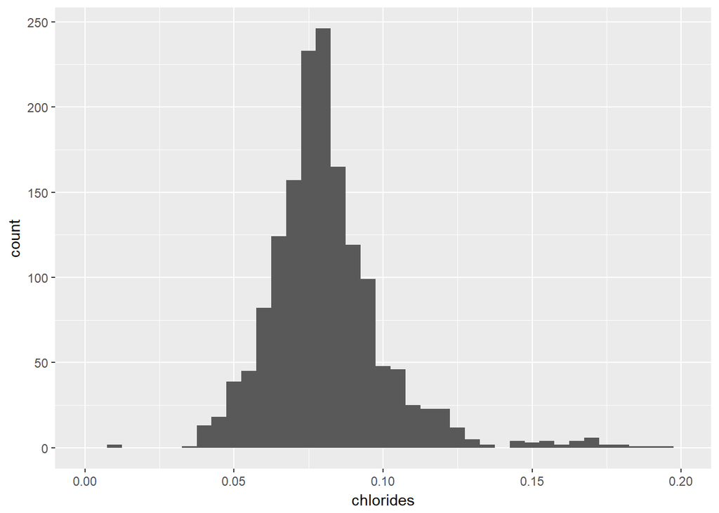

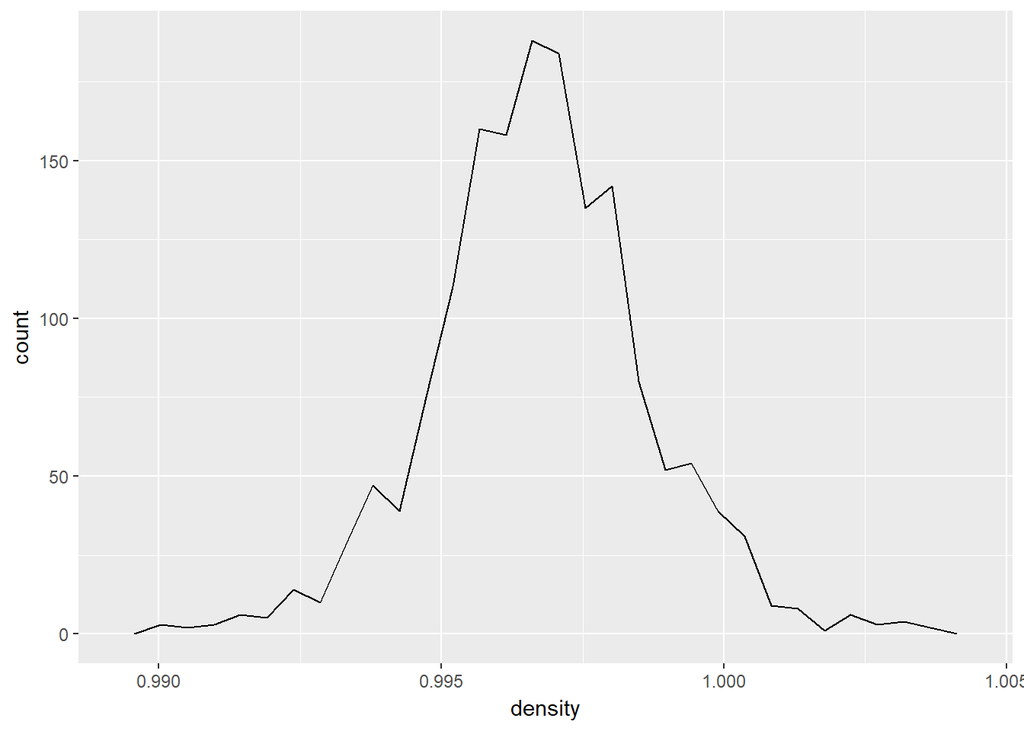

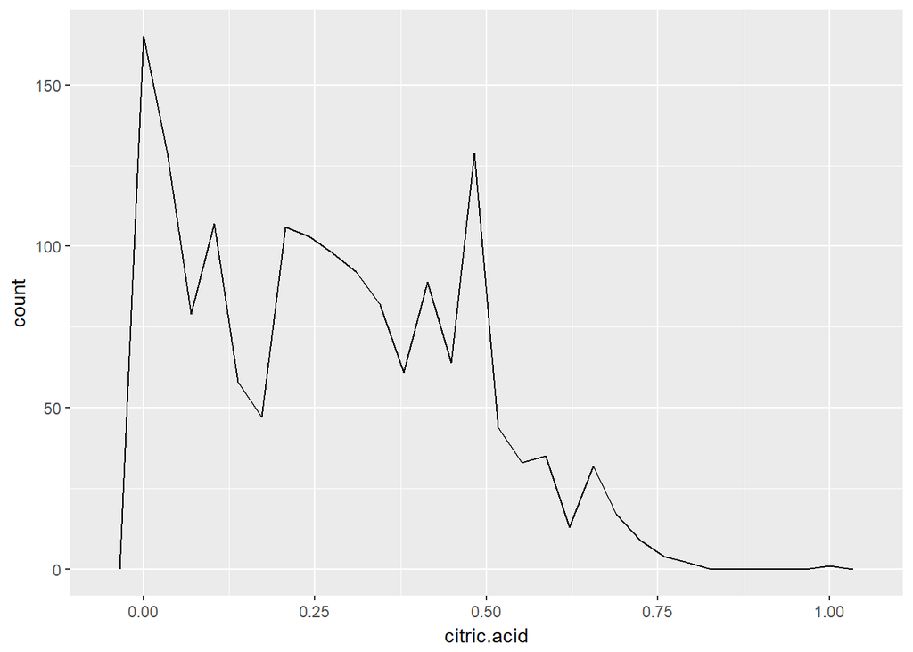

These two line graphs show the normal distribution of density and the non- normal distribution of citric.acid.

# Univariate Analysis

After creating charts for all the variables in the dataset I was pleasently surprised. Most of variable frequencies follow a pretty well defined normal distribution, examples are volatile.acidity and fixed.acidity.

The variables residual.sugar and chlorides and some other variables (to some extent) had some extreme right values. Once the x axis were limited to exclude extreme values the data became more normal.

Something to explore in the bivariate analysis section is the citric.acid variable. It does not appear to have a normal distribution.

Something to note is that over 81% the wine quality scores are either 5 or 6. To get better correlation statistics and figure out what variables affect it would be beneficial to have a wide range of quality scores.

# Bivariate Plots Section

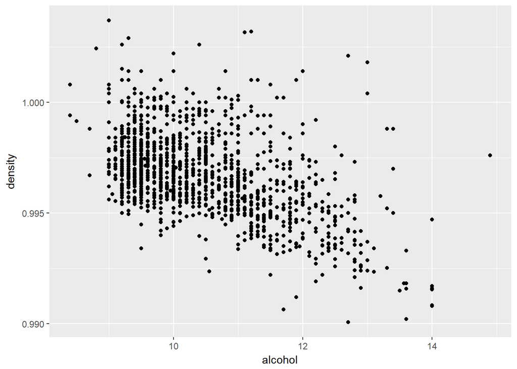

```
##
##  Pearson's product-moment correlation
##
## data:  wineData$alcohol and wineData$density
## t = -22.838, df = 1597, p-value < 2.2e-16
## alternative hypothesis: true correlation is not equal to 0
## 95 percent confidence interval:
##  -0.5322547 -0.4583061
## sample estimates:
##        cor
## -0.4961798
```

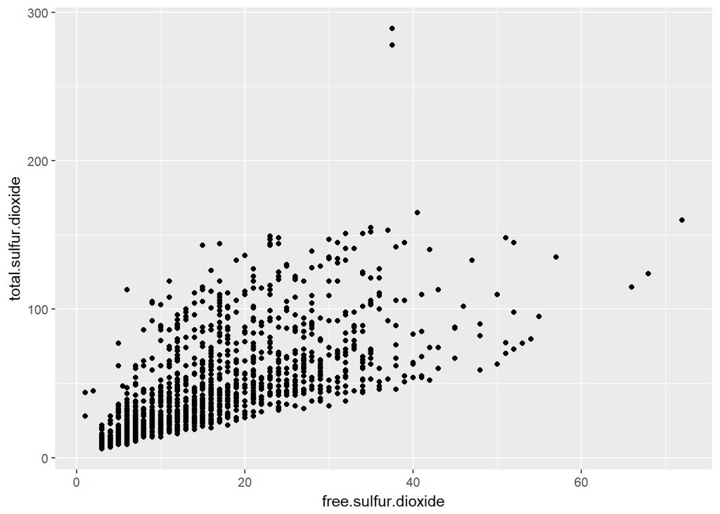

```
##
##  Pearson's product-moment correlation
##
## data:  wineData$free.sulfur.dioxide and wineData$total.sulfur.dioxide
## t = 35.84, df = 1597, p-value < 2.2e-16
## alternative hypothesis: true correlation is not equal to 0
## 95 percent confidence interval:
##  0.6395786 0.6939740
## sample estimates:
##       cor
## 0.6676665
```

First I graphed density vs alcohol which should be negatively correlated since alcohol is less dense than water. A spearson correlation test confirmed it. I did the same for free.sulfur and total.sulfur. Predictably total sulfur was positively correlated with free sulfur.

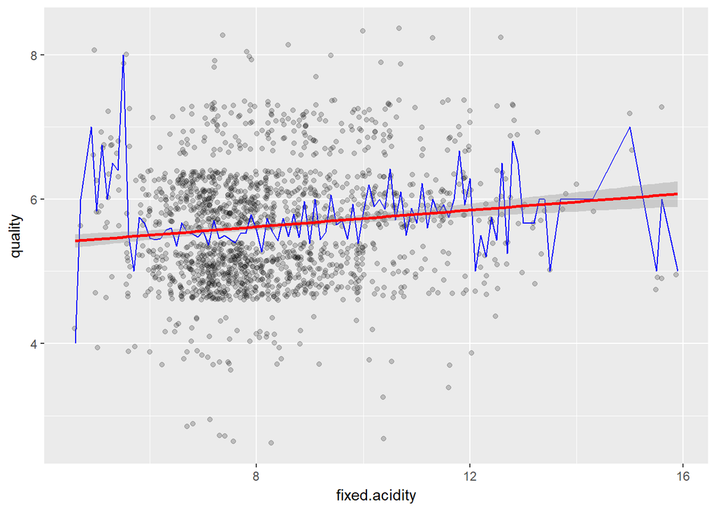

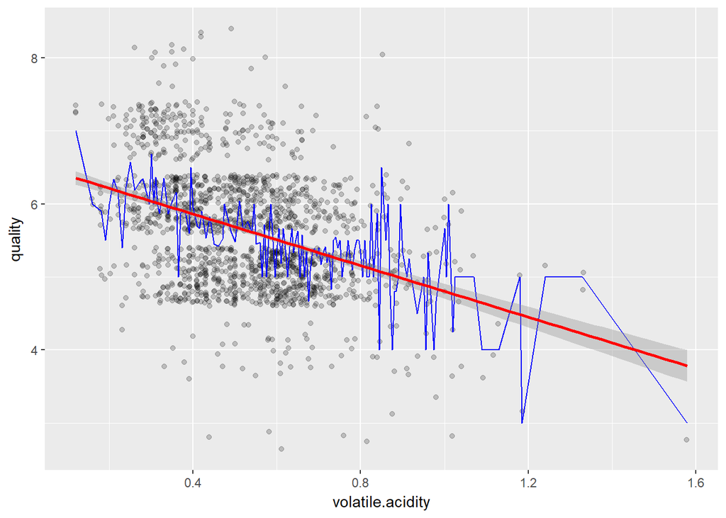

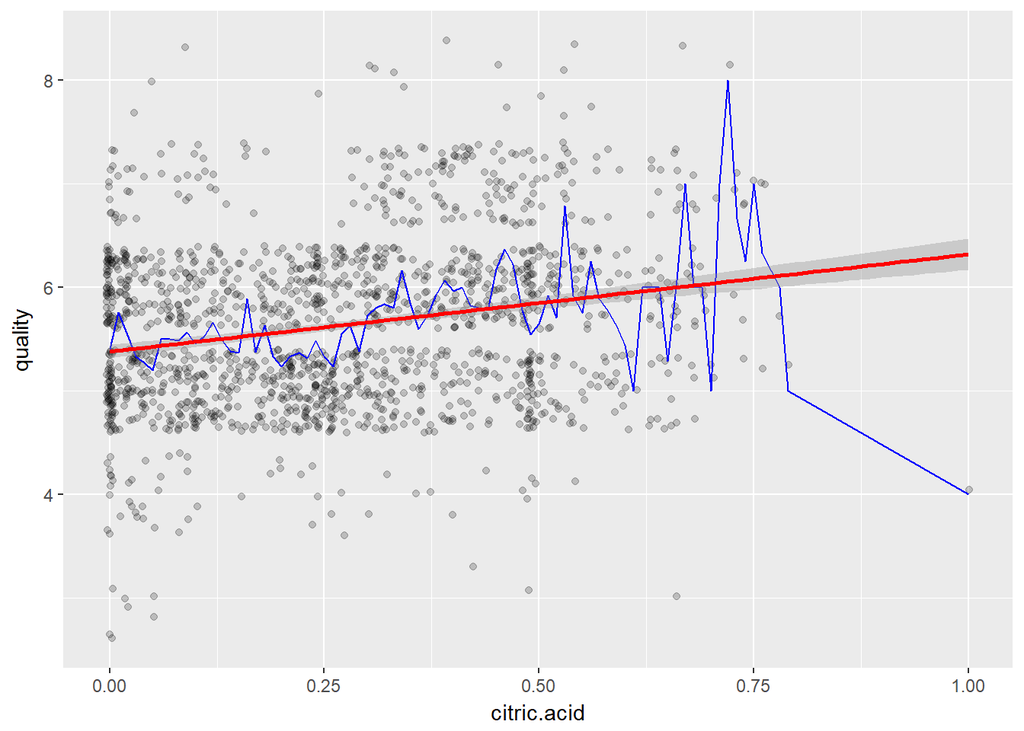

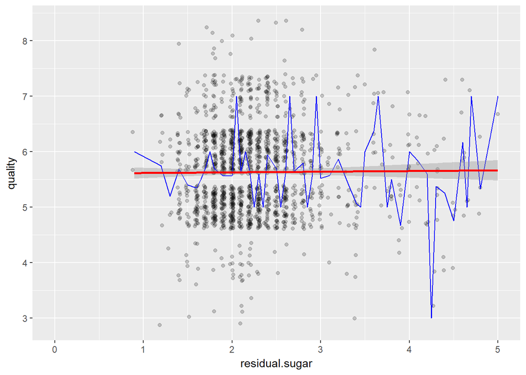

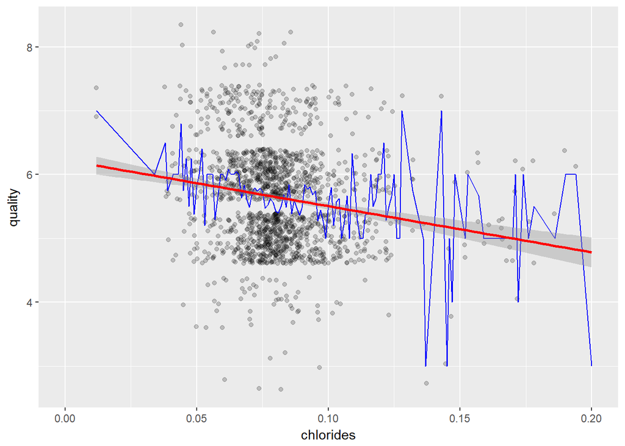

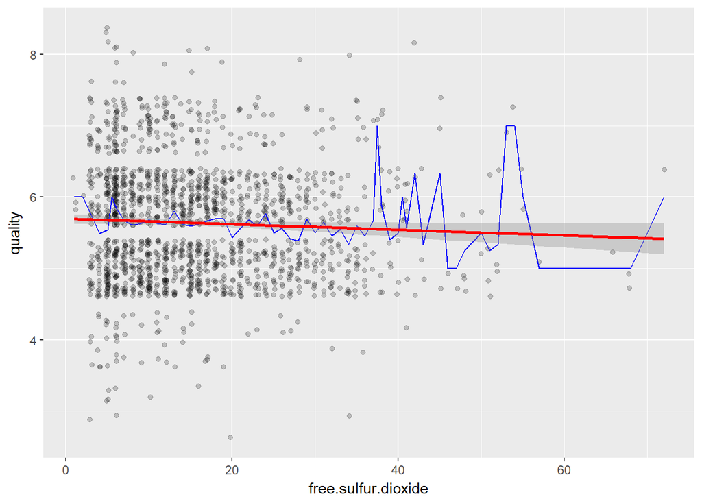

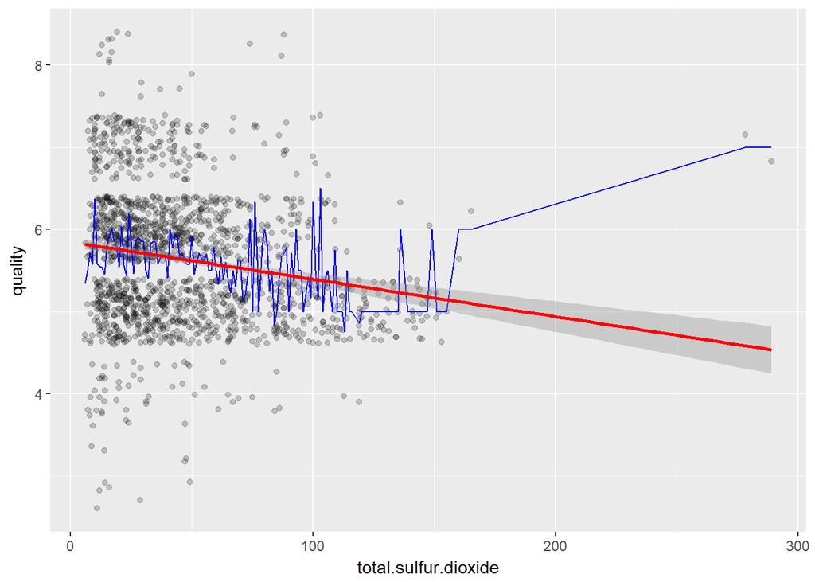

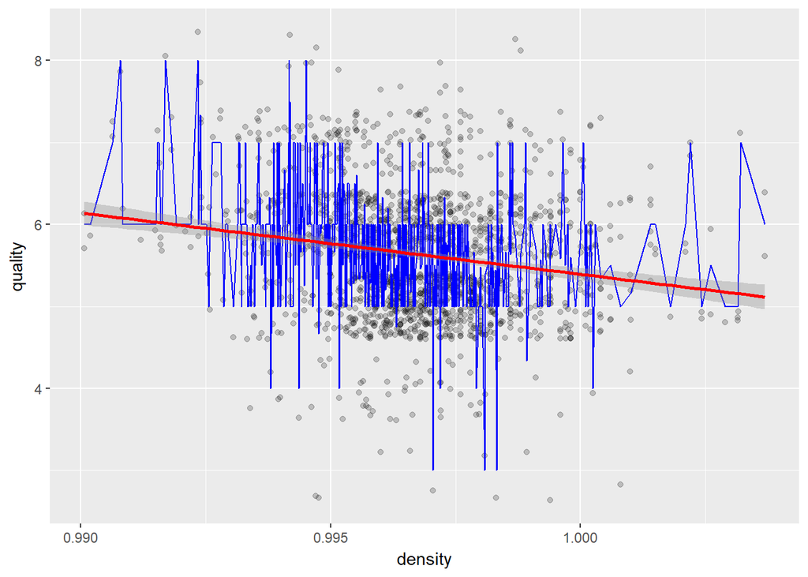

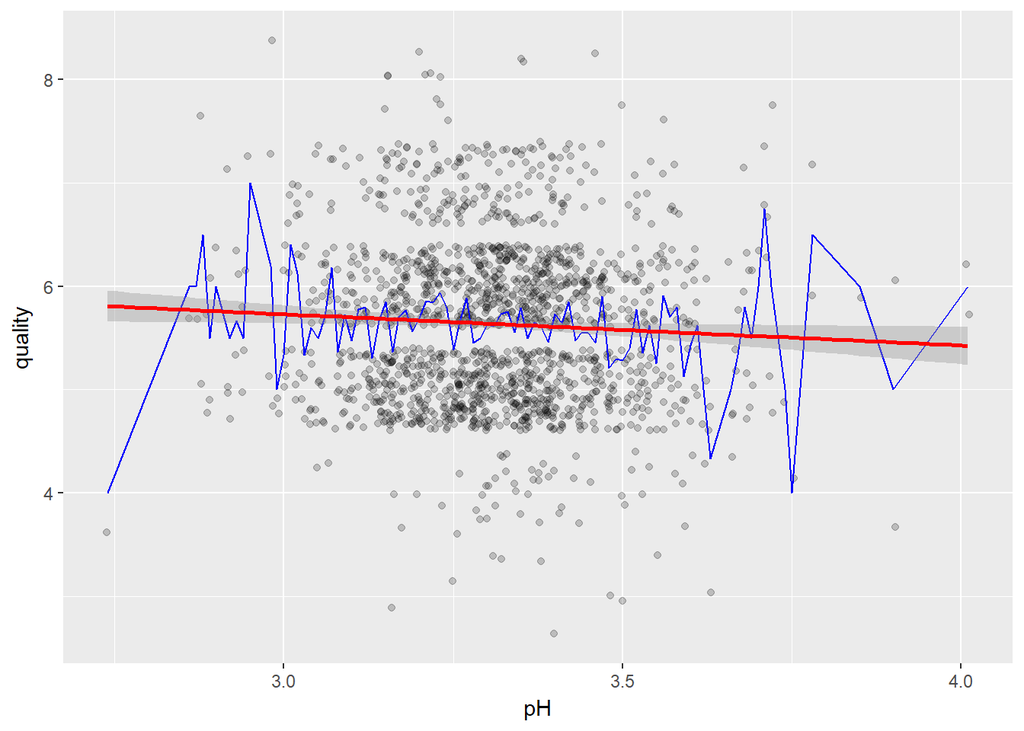

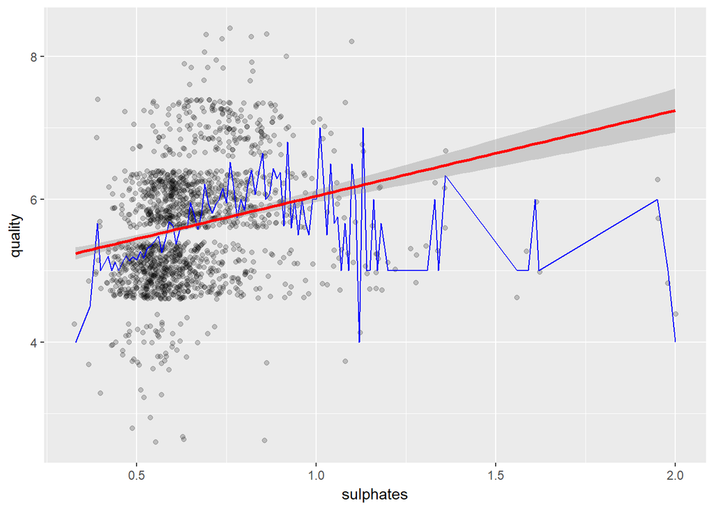

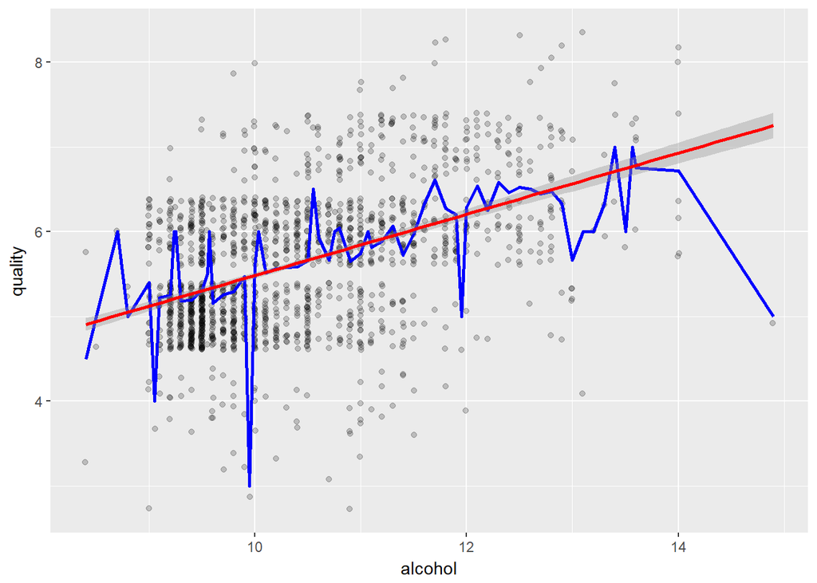

```
##
##  Pearson's product-moment correlation
##
## data:  wineData$alcohol and wineData$quality
## t = 21.639, df = 1597, p-value < 2.2e-16
## alternative hypothesis: true correlation is not equal to 0
## 95 percent confidence interval:
##  0.4373540 0.5132081
## sample estimates:
##       cor
## 0.4761663
```

```
##
##  Pearson's product-moment correlation
##
## data:  wineData$sulphates and wineData$quality
## t = 10.38, df = 1597, p-value < 2.2e-16
## alternative hypothesis: true correlation is not equal to 0
## 95 percent confidence interval:
##  0.2049011 0.2967610
## sample estimates:
##       cor
## 0.2513971
```

```
##
##  Pearson's product-moment correlation
##
## data:  wineData$citric.acid and wineData$quality
## t = 9.2875, df = 1597, p-value < 2.2e-16
## alternative hypothesis: true correlation is not equal to 0
## 95 percent confidence interval:
##  0.1793415 0.2723711
## sample estimates:
##       cor
## 0.2263725
```

```
##
##  Pearson's product-moment correlation
##
## data:  wineData$volatile.acidity and wineData$quality
## t = -16.954, df = 1597, p-value < 2.2e-16
## alternative hypothesis: true correlation is not equal to 0
## 95 percent confidence interval:
##  -0.4313210 -0.3482032
## sample estimates:
##        cor
## -0.3905578
```

# Bivariate Analysis

Next I ran each variable against quality and took note of highly-slopped means and smoothed lines. I identified citric acid, alcohol, volatile.acidity, and sulphates as possible candidates to have a large regression.

After computing the correlation if the 4 identified variables only citric acid had a correlation score between (-0.25,0.25) meaning the correlation was especially weak.

Alcohol had the largest presented correlation to quality which suggests the comical conclusion that a drunk wine tester is a happy wine tester. However future causal research must be performed to verify this.

# Multivariate Plots Section

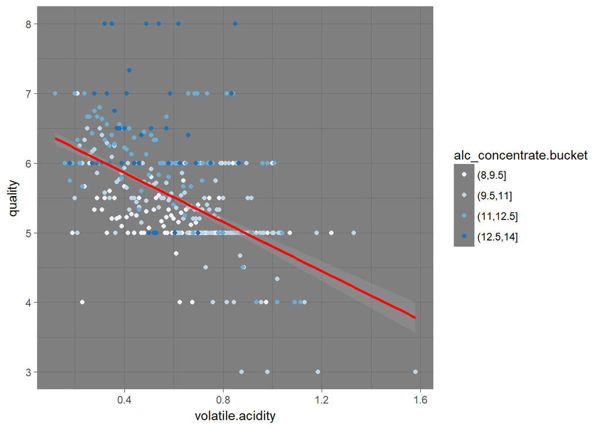

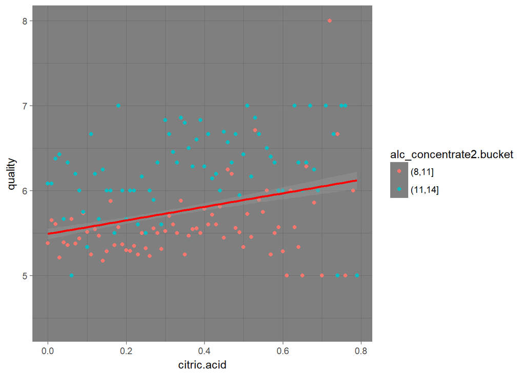

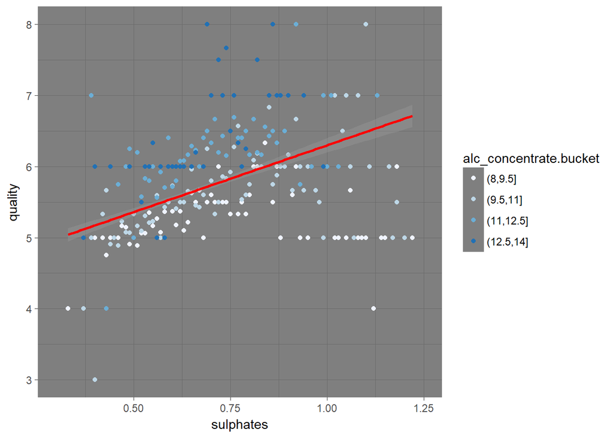

Citric.acid vs quality by alcohol buckets appears to have a positive trend. However it appears (at least visually) that alcohol content has a larger effect on quality than citric acid.

The sulphates vs quality by alcohol buckets has many 7 and 8 rated quality wines in the middle of the x range (around .75)

```
##
## Call:
## glm(formula = quality ~ alcohol + citric.acid + sulphates + volatile.acidity,
##     data = wineData)
##
## Deviance Residuals:
##      Min        1Q    Median        3Q       Max
## -2.71408  -0.38590  -0.06402   0.46657   2.20393
##
## Coefficients:
##                  Estimate Std. Error t value Pr(>|t|)
## (Intercept)       2.64592    0.20106  13.160  < 2e-16 ***
## alcohol           0.30908    0.01581  19.553  < 2e-16 ***
## citric.acid      -0.07913    0.10381  -0.762    0.446
## sulphates         0.69552    0.10311   6.746 2.12e-11 ***
## volatile.acidity -1.26506    0.11266 -11.229  < 2e-16 ***
## ---
## Signif. codes:  0 '***' 0.001 '**' 0.01 '*' 0.05 '.' 0.1 ' ' 1
##
## (Dispersion parameter for gaussian family taken to be 0.4340354)
##
##     Null deviance: 1042.17  on 1598  degrees of freedom
## Residual deviance:  691.85  on 1594  degrees of freedom
## AIC: 3210.2
##
## Number of Fisher Scoring iterations: 2
```

```
##
## Call:
## glm(formula = quality ~ alcohol + sulphates + volatile.acidity,
##     data = wineData)
##
## Deviance Residuals:
##     Min       1Q   Median       3Q      Max
## -2.7186  -0.3820  -0.0641   0.4746   2.1807
##
## Coefficients:
##                  Estimate Std. Error t value Pr(>|t|)
## (Intercept)       2.61083    0.19569  13.342  < 2e-16 ***
## alcohol           0.30922    0.01580  19.566  < 2e-16 ***
## sulphates         0.67903    0.10080   6.737 2.26e-11 ***
## volatile.acidity -1.22140    0.09701 -12.591  < 2e-16 ***
## ---
## Signif. codes:  0 '***' 0.001 '**' 0.01 '*' 0.05 '.' 0.1 ' ' 1
##
## (Dispersion parameter for gaussian family taken to be 0.4339214)
##
##     Null deviance: 1042.2  on 1598  degrees of freedom
## Residual deviance:  692.1  on 1595  degrees of freedom
## AIC: 3208.8
##
## Number of Fisher Scoring iterations: 2
```

```
## [1] 6
```

```
##      250
## 5.517828
```

```
## [1] 6
```

```
##     500
## 5.85747
```

```
##    Min. 1st Qu.  Median    Mean 3rd Qu.    Max.
##   3.000   5.000   6.000   5.636   6.000   8.000
```

```
##    Min. 1st Qu.  Median    Mean 3rd Qu.    Max.
##   4.323   5.279   5.580   5.636   5.970   7.349
```

After visually inspecting all the graphs I attempted to fit quality to be dependent on citric.acid, sulphates, volatile.acidity and alcohol. The results had very poor confidence intervals. The best performing parameters was alchol, sulphates and volatile.acidity. Running that fitted model was much better as most variables had a 99.9% confidence interval.

I then pulled the quality score for observation 250, which was six and ran it against the model which predicted 5.52 (rounded up thats 6). Obervation 500 had a quality score of 6 and the fitted model predicted 5.86 which is pretty close.

# Multivariate Analysis

After separating alcohol content into four buckets and running scatter plots on the other three identified variables several trends became apparent. Alcohol had the largest effect on quality of content. Very few highly rated wines were in the two lower alcohol groups. Additionally because of interaction between volatile.acids and citric.acid one of the two had to be dropped from the fitted model.

# Final Plots and Summary

### Plot One

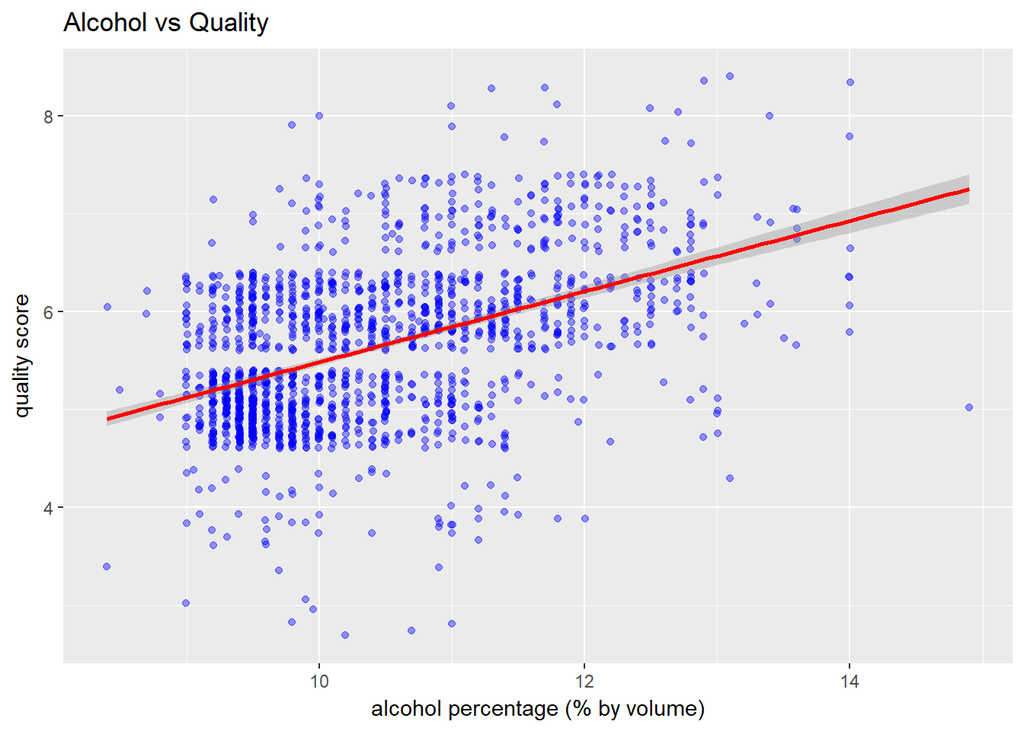

### Description One

I chose this graph because it illustrates the highest single factor correlation to a wine’s quality score. The wines with higher alcohol appear to on average to have higher scores. The red fitted line confirms our visual observation.

### Plot Two

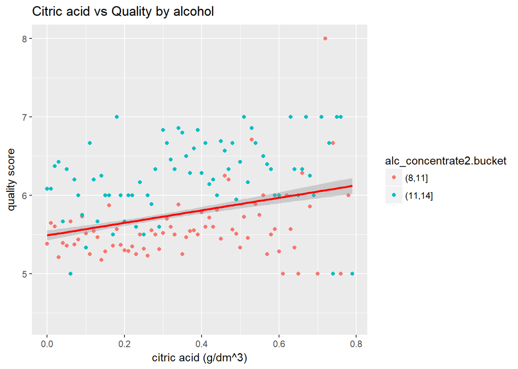

### Plot Three

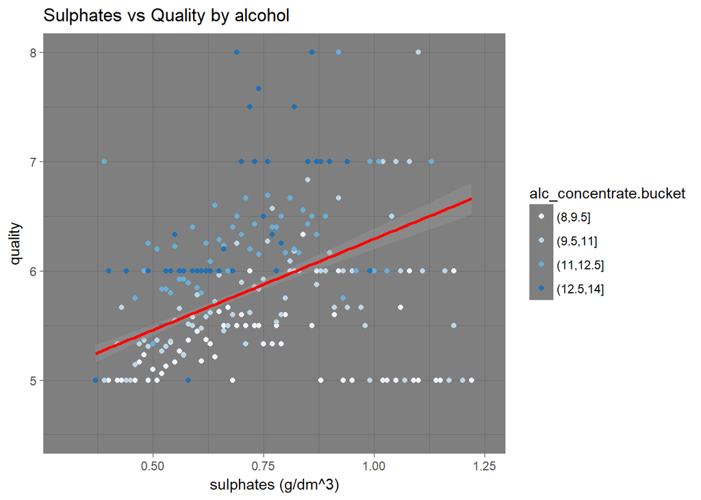

### Description Three

I chose the sulphates vs quality plot because it displays how values further from the fitted mean can accentuate its slope. There are many more wines with the two lower levels of alcohol content than the two higher ones. Additionaly the few high quality wines tend to have a higher alcohol content, either due to causation or due to sampling. This fact drives the fitted mean line to a more pronounced slope. ——

# Reflection

Future analysis of this dataset should focus on developing and testing various predictive models. These models can then be tested against new observations to test its efficacy. I read online that it is possible to randomly use only half a data set to create a model and then have it tested against the remaining half. It would be interesting to do this procedure and statistically evaluate it.